# College Scorecard Notes

### Data

Not each year has data for each variable, they changed what they collected over the years.

NA’s are called NULL’s.

This is the data selection.

```r
# get one file for now from 11-12
# data <- read.csv("../college_data/MERGED2011_12_PP.csv", na.strings = "NULL")
# variables to selet
colNames <- c("OPEID","OPEID6","MD_EARN_WNE_P10", "MD_EARN_WNE_P6", "MN_EARN_WNE_P6", "MN_EARN_WNE_P10",
               "MD_FAMINC", "DEP_INC_AVG", "IND_INC_AVG",
              "MN_EARN_WNE_INDEP0_P10", "MN_EARN_WNE_INDEP1_P10")
colNums <- match(colNames, names(data))
four_year <- data %>%
  #na.omit() %>%
  filter(ICLEVEL == 1) %>%
  select(colNums) %>%
  filter(complete.cases(.)) %>%
  distinct()
# convert factors to numeric
four_year[colNames] <- sapply(four_year[colNames], as.character)
four_year[colNames] <- sapply(four_year[colNames], as.numeric)
#remove newly introduced NAs by numericizing
four_year <- na.omit(four_year)
```

### Select good earners

Want a metric to the effect of ‘this school produces good earners.’ Picking one number, say above 50k, would not account for correlation between family income and college grad income. Make a very rudimentary first order correction for this - plots below show mean income 10 years after enrollment as a function of family income at time of enrollment.

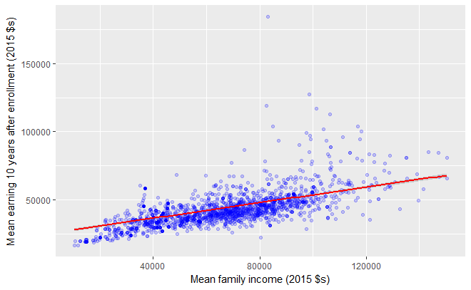

```r
# linear fit
p_lin <- ggplot(four_year, aes(x = DEP_INC_AVG, y = MN_EARN_WNE_INDEP0_P10)) +
  geom_point(alpha = 0.2, color = "blue") +
  geom_smooth(method = "lm", formula = y ~ x, color = "red") +
  xlab("Mean family income (2015 $s)") +
  ylab("Mean earning 10 years after enrollment (2015 $s)")
p_lin
```

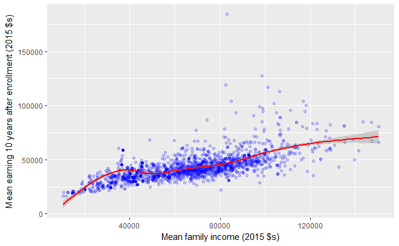

```r
p2 <- ggplot(four_year, aes(x = DEP_INC_AVG, y = MN_EARN_WNE_INDEP0_P10)) +
  geom_point(alpha = 0.2, color = "blue") +
  geom_smooth(color = "red") +
  xlab("Mean family income (2015 $s)") +
  ylab("Mean earning 10 years after enrollment (2015 $s)")
p2
```

That’s basically three lines. (Well, ok. Not really.) Let’s see anyway. Lines may be easier to cut on.

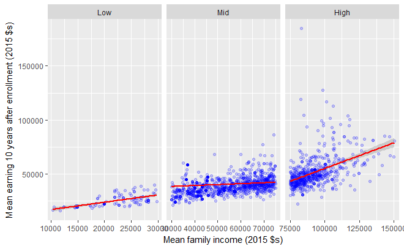

```r
# Add facet for parents' income bracket
four_year <- mutate(four_year, fam_bracket = ifelse(DEP_INC_AVG < 30000, "Low",
                        ifelse(DEP_INC_AVG > 75000, "High", "Mid")))
# Make facets into factors - orders better in ggplot
four_year$fam_bracket_f <- factor(four_year$fam_bracket, levels = c("Low", "Mid", "High"))
p_bracket <- ggplot(four_year, aes(x = DEP_INC_AVG, y = MN_EARN_WNE_INDEP0_P10)) +
  geom_point(alpha = 0.2, color = "blue") +
  geom_smooth(method = "lm", formula = y ~ x, color = "red") +
  xlab("Mean family income (2015 $s)") +
  ylab("Mean earning 10 years after enrollment (2015 $s)") +
  facet_grid(. ~ fam_bracket_f, scale = "free")
p_bracket
```

This is somewhat meaningful, but the dots are schools, not students. The goal was to come up with a non-horizontal line above which one might call ‘alumni make good money’ without biasing against low income. A bit of an arbitrary cut - will need to investigate further what I am leaving out.

Turns out it’s difficult to extract the fit results from ggplot. (Some hacky ways on stack overflow, but do the fits standalone instead).

Here are the three lines:

```r
fitLo <- lm(formula = MN_EARN_WNE_INDEP0_P10 ~ DEP_INC_AVG,
          data = four_year, fam_bracket_f == "Low")
summary(fitLo)
```

```
Call:
lm(formula = MN_EARN_WNE_INDEP0_P10 ~ DEP_INC_AVG, data = four_year,
    subset = fam_bracket_f == "Low")

Residuals:
   Min     1Q Median     3Q    Max
 -6782  -2545  -1051   1990  10126

Coefficients:
             Estimate Std. Error t value Pr(>|t|)
(Intercept) 1.031e+04  1.734e+03   5.944 3.39e-08 ***
DEP_INC_AVG 6.766e-01  7.674e-02   8.818 2.10e-14 ***
---
Signif. codes:  0 ‘***’ 0.001 ‘**’ 0.01 ‘*’ 0.05 ‘.’ 0.1 ‘ ’ 1

Residual standard error: 4080 on 109 degrees of freedom
Multiple R-squared:  0.4163,    Adjusted R-squared:  0.411
F-statistic: 77.76 on 1 and 109 DF,  p-value: 2.101e-14
```

```r
fitMd <- lm(formula = MN_EARN_WNE_INDEP0_P10 ~ DEP_INC_AVG,
            data = four_year, fam_bracket_f == "Mid")
summary(fitMd)
```

```
Call:
lm(formula = MN_EARN_WNE_INDEP0_P10 ~ DEP_INC_AVG, data = four_year,
    subset = fam_bracket_f == "Mid")

Residuals:
   Min     1Q Median     3Q    Max
-17269  -5457  -1134   4070  44311

Coefficients:
             Estimate Std. Error t value Pr(>|t|)
(Intercept) 3.585e+04  8.726e+02  41.079  < 2e-16 ***
DEP_INC_AVG 8.550e-02  1.648e-02   5.188 2.44e-07 ***
---
Signif. codes:  0 ‘***’ 0.001 ‘**’ 0.01 ‘*’ 0.05 ‘.’ 0.1 ‘ ’ 1

Residual standard error: 8009 on 1404 degrees of freedom
Multiple R-squared:  0.01881,   Adjusted R-squared:  0.01811
F-statistic: 26.92 on 1 and 1404 DF,  p-value: 2.436e-07
```

```r
fitHi <- lm(formula = MN_EARN_WNE_INDEP0_P10 ~ DEP_INC_AVG,
            data = four_year, fam_bracket_f == "High")
summary(fitHi)
```

```
Call:
lm(formula = MN_EARN_WNE_INDEP0_P10 ~ DEP_INC_AVG, data = four_year,
    subset = fam_bracket_f == "High")

Residuals:
   Min     1Q Median     3Q    Max
-30081  -5954  -1527   2563 137225

Coefficients:
             Estimate Std. Error t value Pr(>|t|)
(Intercept) 8.025e+03  3.292e+03   2.438    0.015 *
DEP_INC_AVG 4.720e-01  3.542e-02  13.328   <2e-16 ***
---
Signif. codes:  0 ‘***’ 0.001 ‘**’ 0.01 ‘*’ 0.05 ‘.’ 0.1 ‘ ’ 1

Residual standard error: 12550 on 665 degrees of freedom
Multiple R-squared:  0.2108,    Adjusted R-squared:  0.2096
F-statistic: 177.6 on 1 and 665 DF,  p-value: < 2.2e-16
```

The goodness of these is not a big deal - they are somewhat arbitrary lines, and not actually used as a fit result. Let’s make sure that these are the same as what ggplot gave.

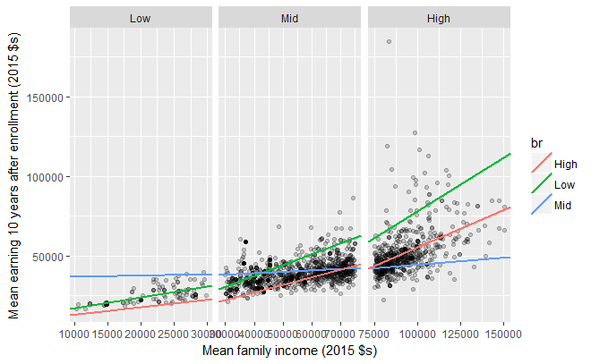

```r
# get the slope and intercept into its own df, kind of hacky to get legend right
fits <- data.frame(m = c(summary(fitLo)$coeff[2],
                           summary(fitMd)$coeff[2],
                           summary(fitHi)$coeff[2]),
                  b = c(summary(fitLo)$coeff[1],
                               summary(fitMd)$coeff[1],
                               summary(fitHi)$coeff[1]),
                  br = c("Low", "Mid", "High"))
p_bracket_manual <- ggplot(four_year, aes(x = DEP_INC_AVG,
                                          y = MN_EARN_WNE_INDEP0_P10)) +
  geom_point(alpha = 0.2) +
  geom_abline(aes(slope = m, intercept = b, color = br),size = 1, data = fits) +
  xlab("Mean family income (2015 $s)") +
  ylab("Mean earning 10 years after enrollment (2015 $s)") +
  facet_grid(. ~ fam_bracket_f, scale = "free")
p_bracket_manual
```

The lines are the same: Good. This plot is ugly at the moment, but plotting all the lines on all the brackets was informative.

- Low income students more likely than mid or high to do better than their parents, which makes their standard of doing better than their parents too high a bar for mid to hihg income students.
- Mid and high income students bracket widths get cut righ in the middle, causing ill fits. One option is to come up with a better binning, but this is the binning that the dataset aggregated many ready-to-use variables. Long term - do my own binning and use numbers, not means and percentiles from data.
- Bottom line: Stick with original plan to select above each bracket’s line.

```r
# Simple function to determine if graduates of school
# are considered good earners
good_earner <- function(y, x, bracket){
  slope = fits[fits$br == bracket,"m"]
  #print(slope)
  intercept = fits[fits$br == bracket,"b"]
  #print(intercept)

  if (y >= slope*x + intercept){
    #print("True")
    return(TRUE)
  }
  else{
    #print("False")
    return(FALSE)
    }
}
# test <- good_earner(2000, 20000, "Low")
# add earning column
four_year_earn <- four_year %>%
  rowwise() %>%
  mutate(earnings = ifelse(good_earner(MN_EARN_WNE_INDEP0_P10,
                                            DEP_INC_AVG,
                                            fam_bracket),"Above", "Below"))
# Get IDs of selection so far to bind to full dataset
earn_id <- four_year_earn %>%
  select(OPEID, OPEID6, fam_bracket_f, earnings)

# Bind this with full dataset to keep only the selected schools but all variables
keep_schools <- merge(data, earn_id, by=c("OPEID","OPEID6"))
keep_schools <- subset(keep_schools, !duplicated(keep_schools[,"OPEID"]))
```

Let’s check that the remaining data is above the cut line.

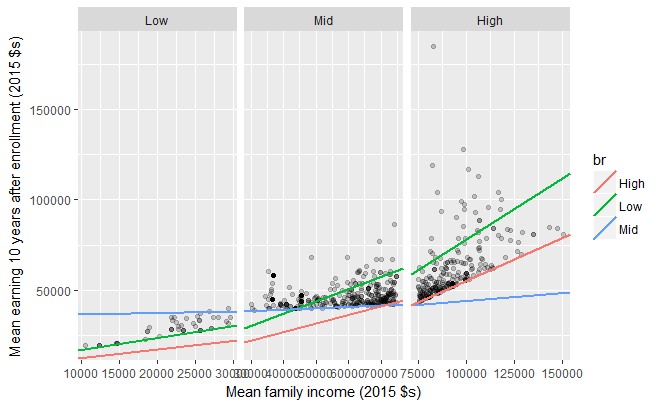

```r
p_good <- ggplot(data = subset(four_year_earn, earnings=="Above"), aes(x = DEP_INC_AVG,
                                          y = MN_EARN_WNE_INDEP0_P10)) +
  geom_point(alpha = 0.2) +
  geom_abline(aes(slope = m, intercept = b, color = br),size = 1, data = fits) +
  xlab("Mean family income (2015 $s)") +
  ylab("Mean earning 10 years after enrollment (2015 $s)") +
  facet_grid(. ~ fam_bracket_f, scale = "free")
p_good
```

Seems to have worked! The selection is greater than or equal to - that’s why there are dots in the boundary.

One thing to note is that this is not a robust definition of producing good earner by any means. Next iteration of analysis needs to include a (much) better selection method than this arbitrary line. But let’s keep going with building the skeleton.

### Predict good schools?

Can I predict schools that will produce good earners? R has a built in knn function - start there.

```r
gradVars <- c("C150_4", #completion rate
              "COSTT4_A", #average cost of attendance academic year
              "TUITFTE", #Net tuition revenue per full-time equivalent student
              "INEXPFTE", #Instructional expenditures per full-time equivalent student
              "ADM_RATE", #Admission rate overall
              "SAT_AVG", #Average SAT equivalent score of students admitted
              "UGDS", #Enrollment of all undergraduate students
              "AVGFACSAL", #Average faculty salary
              "PFTFAC", #Ratio of full-time faculty
              "DEBT_MDN", #Median debt
              "PAR_ED_PCT_1STGEN", #percentage of first-gen students
              "earnings" #Earnings Above or Below
)
```

**TO DO:** This list of parameters have been chosen extremly subjectively. I selected them by scrolling down the data dictionary. I deliberately avoided potentially good predictors such as race because I want to find school parameters, not social ones. Future iterations need to more quantitatively onbectively make this selection, maybe clean up the data and throw a principle components analysis at it? I used the same set that I used to predict graduation rate.

```r
colGradVars <- match(gradVars, names(keep_schools))
knnSample <- select(keep_schools, colGradVars)
#convert all but earnings to numeric (they ae already chr)
numeric.num <- match(gradVars[1:length(gradVars)-1], names(knnSample))
knnSample[numeric.num] <- sapply(knnSample[numeric.num], as.numeric)
#remove NAs from converting
knnSample <- knnSample[complete.cases(knnSample),]
#normalize columns to same scale
normalize <- function(x){
  if(!is.numeric(x)){
    return(x)
  }else{
    norm_x <- (x-min(x))/(max(x) - min(x))
    return(norm_x)
  }
}
knnNorm <- as.data.frame(sapply(knnSample, normalize))
#training and test samples
# Sample into training and test sets
set.seed(123)
trn <- sample(seq_len(nrow(knnNorm)), size = floor(.75 * nrow(knnNorm)))
train <- knnNorm[trn, ]
test <- knnNorm[-trn, ]
#run knn
kn <- floor(sqrt(nrow(train)))
pred.knn <- knn(train = train[, 1:11], test = test[, 1:11], cl = train[, 12],
                   k = kn)
table(test[,12],pred.knn)
```

```
       pred.knn
        Above Below
  Above    44    58
  Below    18   140
```

```r
prop.table(table(test[,12],pred.knn))
```

```
       pred.knn
             Above      Below
  Above 0.16923077 0.22307692
  Below 0.06923077 0.53846154
```

Not very good. Biases heavily towards Below. Manually check a few other k’s.

```r
pred.knn_5 <- knn(train = train[, 1:11], test = test[, 1:11], cl = train[, 12],
                k = 5)
pred.knn_11 <- knn(train = train[, 1:11], test = test[, 1:11], cl = train[, 12],
                k = 11)
pred.knn_19 <- knn(train = train[, 1:11], test = test[, 1:11], cl = train[, 12],
                k = 19)
table(test[,12],pred.knn_5)
```

```
       pred.knn_5
        Above Below
  Above    56    46
  Below    33   125
```

```r
table(test[,12],pred.knn_11)
```

```
       pred.knn_11
        Above Below
  Above    53    49
  Below    20   138
```

```r
table(test[,12],pred.knn_19)
```

```
       pred.knn_19
        Above Below
  Above    48    54
  Below    19   139
```

They perform about equally well. To answer the hard question - out of these (then, out of more variables) which ones are predictive.

### Improve kNN

This biserial correlation function seems potentially useful. Here’s some play with it.

**TO DO:** Determine which variables to use in the knn - I don’t yet understand this function well enough.

|  | Variable | bicorr |
| --- | --- | --- |
| 1 | AVGFACSAL | 0.436875191 |
| 2 | UGDS | 0.308446351 |
| 3 | INEXPFTE | 0.299704449 |
| 4 | SAT_AVG | 0.247833291 |
| 5 | C150_4 | 0.158127865 |
| 6 | ADM_RATE | -0.151334043 |
| 7 | TUITFTE | 0.083034847 |
| 8 | PAR_ED_PCT_1STGEN | -0.039034387 |
| 9 | COSTT4_A | 0.020332370 |
| 10 | PFTFAC | 0.018923495 |

[output cut: 1 more lines]

With this set of variables, try to find combinations that work better.

improve_knn.R tries all combinations of 3-11 parameters out of these 11: a total of 1981 samples) and orders them by knn accuracy. The accuracies range between .75 and .57.

**TO DO**

- Define “good earning” well and write a robust sample selector
- Select predictor variables systematically
- Other algorihtms than the built in kNN to predict “good earner”
- What variables predict good schools for what subset of the population?